# Clustering Kaisaniemi

```r
library("rjson")
library(dplyr)
library(tidyverse)
# Give the input file name to the function.
MeasurementData_2410 <- fromJSON(file ="C:/Users/iced/Documents/HY/Year1/DS project/data/2410.json") %>% as.data.frame #fromJSON()
MeasurementData_2410<-gather(MeasurementData_2410,"Timestamp","Value",3:18625)
```

Remove metrics word

```r
MeasurementData_2410$Timestamp<-substring(MeasurementData_2410$Timestamp, 9, nchar(MeasurementData_2410$Timestamp))
MeasurementData_2410$Timestamp<-as.POSIXct(as.numeric(as.character(MeasurementData_2410$Timestamp)),origin="1970-01-01",tz="GMT")
```

Divide data into CO2 and temp, remove ‘setpoint’ data

```r
MeasurementData_2410_co2<-MeasurementData_2410[substring(MeasurementData_2410$fields,10,12)=='co2',]
MeasurementData_2410_co2<-MeasurementData_2410_co2[!substring(MeasurementData_2410_co2$fields,14,15)=='se',]
MeasurementData_2410_temp<-MeasurementData_2410[!substring(MeasurementData_2410$fields,10,12)=='co2',]
MeasurementData_2410_temp<-MeasurementData_2410_temp[!substring(MeasurementData_2410_temp$fields,15,16)=='se',]
```

distinct check

```r
unique(MeasurementData_2410_temp$fields)
```

```
 [1] room_114_temp room_214_temp room_215_temp room_315_temp
 [5] room_317_temp room_327_temp room_408_temp room_409_temp
 [9] room_508_temp room_509_temp room_134_temp room_216_temp
[13] room_217_temp room_318_temp room_319_temp room_411_temp
[17] room_510_temp room_511_temp room_106_temp room_404_temp
[21] room_405_temp room_504_temp room_505_temp room_506_temp
98 Levels: room_106_co2 room_106_co2_setpoint ... room_511_temp_setpoint
```

Adding more time columns (hour,weekday,month)

```r
library(chron)
MeasurementData_2410_co2$Hour=hours(MeasurementData_2410_co2$Timestamp)
MeasurementData_2410_co2$Weekday=weekdays(MeasurementData_2410_co2$Timestamp)
MeasurementData_2410_co2$Month=months(MeasurementData_2410_co2$Timestamp)
MeasurementData_2410_co2$Room<-substring(MeasurementData_2410_co2$fields,6,8)
#same for temperature
MeasurementData_2410_temp$Hour=hours(MeasurementData_2410_temp$Timestamp)
MeasurementData_2410_temp$Weekday=weekdays(MeasurementData_2410_temp$Timestamp)
MeasurementData_2410_temp$Month=months(MeasurementData_2410_temp$Timestamp)
MeasurementData_2410_temp$Room<-substring(MeasurementData_2410_temp$fields,6,8)
```

Subsetting data to be from 8 AM to 18 PM and from Monday to Friday

```r
MeasurementData_2410_co2 <- MeasurementData_2410_co2[ which(MeasurementData_2410_co2$Hour>=8
& MeasurementData_2410_co2$Hour <= 18), ] #ok
MeasurementData_2410_co2 <- MeasurementData_2410_co2[which(MeasurementData_2410_co2$Weekday != "Saturday" & MeasurementData_2410_co2$Weekday != "Sunday"), ]
MeasurementData_2410_temp <- MeasurementData_2410_temp[ which(MeasurementData_2410_temp$Hour>=8
& MeasurementData_2410_temp$Hour <= 18), ] #ok
MeasurementData_2410_temp<-MeasurementData_2410_temp[which(MeasurementData_2410_temp$Weekday != "Saturday" & MeasurementData_2410_temp$Weekday != "Sunday"), ]
```

Aggregating the data to be mean CO2 per hour

```r
aggred <- aggregate(MeasurementData_2410_co2[4], list(Room=MeasurementData_2410_co2$Room,Hour=MeasurementData_2410_co2$Hour), mean)
```

Same for tempreature

```r
aggredtemp <- aggregate(MeasurementData_2410_temp[4], list(Room=MeasurementData_2410_temp$Room,Hour=MeasurementData_2410_co2$Hour), mean)
```

Plotting the dataset

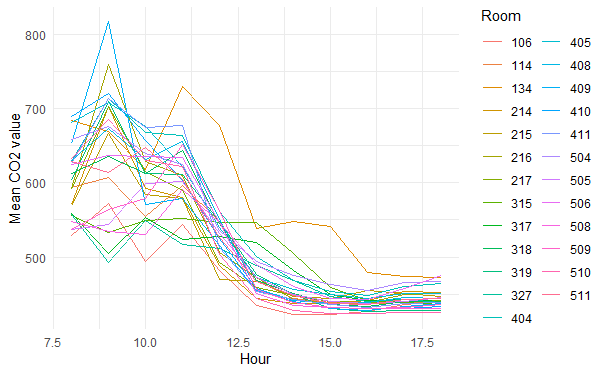

```r
aggred %>%
  ggplot( aes(x=Hour, y=Value, group=Room, color=Room)) +
    geom_line() + ylab("Mean CO2 value")+theme_minimal()
```

Same for temp

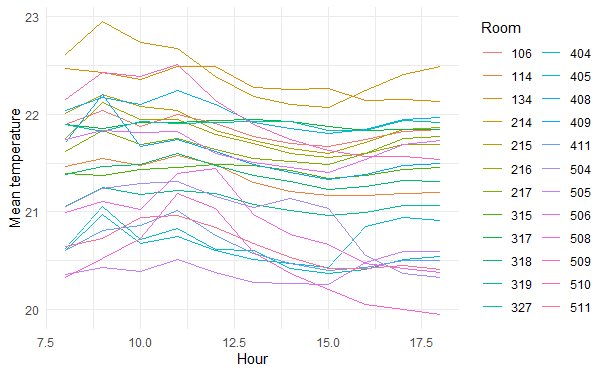

```r
aggredtemp %>%
  ggplot( aes(x=Hour, y=Value, group=Room, color=Room)) +
    geom_line() + ylab("Mean temperature")+theme_minimal()
```

Drop NAs to perform clustering

```r
aggred <- aggred %>%
  select(Room, Hour, Value) %>%
  drop_na() %>% # must drop NAs for clustering to work
  glimpse()
```

```
Observations: 275
Variables: 3
$ Room  <chr> "106", "114", "134", "214", "215", "216", "217", "315...
$ Hour  <dbl> 8, 8, 8, 8, 8, 8, 8, 8, 8, 8, 8, 8, 8, 8, 8, 8, 8, 8,...
$ Value <dbl> 528.7258, 593.8548, 684.5143, 570.8943, 569.1918, 591...
```

Create a data frame using the spread() function that lists every Room with the mean CO2 value per hour

```r
spread_aggred <- aggred %>%
  spread(Room, Value)  %>%
  glimpse()
```

```
Observations: 11
Variables: 26
$ Hour  <dbl> 8, 9, 10, 11, 12, 13, 14, 15, 16, 17, 18
$ `106` <dbl> 528.7258, 572.3828, 493.6828, 544.3674, 481.2742, 435...
$ `114` <dbl> 593.8548, 607.0165, 554.4695, 596.1057, 548.0986, 467...
$ `134` <dbl> 684.5143, 669.6502, 618.0538, 729.9516, 676.6828, 538...
$ `214` <dbl> 570.8943, 703.2723, 592.4588, 579.6756, 488.8154, 443...
$ `215` <dbl> 569.1918, 665.9670, 584.4319, 578.4337, 469.4570, 466...
$ `216` <dbl> 591.9677, 758.7789, 629.3297, 609.5735, 506.5448, 472...
$ `217` <dbl> 591.5394, 702.6403, 615.1649, 589.9068, 493.0394, 458...
$ `315` <dbl> 555.4032, 532.9488, 548.8674, 551.4247, 546.2384, 546...
$ `317` <dbl> 558.3136, 504.2112, 552.9928, 523.4444, 527.1416, 520...
$ `318` <dbl> 612.7419, 635.1089, 612.7330, 643.4498, 545.1559, 468...
$ `319` <dbl> 602.8710, 709.1502, 612.7419, 611.6989, 548.2151, 476...
$ `327` <dbl> 557.0663, 492.7013, 549.2903, 517.2025, 511.4964, 488...
$ `404` <dbl> 628.6326, 713.5495, 668.4427, 664.0215, 561.6577, 501...
$ `405` <dbl> 680.8029, 707.6023, 676.3996, 622.3763, 539.9839, 472...
$ `408` <dbl> 630.2401, 673.1733, 630.8082, 655.5305, 550.9014, 457...
$ `409` <dbl> 652.5878, 816.6749, 570.5269, 579.3584, 515.0376, 454...
$ `410` <dbl> 689.6201, 720.9109, 657.1505, 603.0968, 524.8136, 458...
$ `411` <dbl> 626.3190, 714.0479, 673.9821, 677.1989, 512.6075, 453...
$ `504` <dbl> 658.6272, 675.7409, 639.5090, 624.4677, 535.8136, 494...
$ `505` <dbl> 536.8943, 544.3911, 599.4140, 601.7742, 532.2616, 471...
$ `506` <dbl> 625.0824, 637.3234, 635.6613, 634.1738, 546.4731, 489...
$ `508` <dbl> 548.5824, 534.9208, 530.7939, 590.5466, 546.0771, 451...
$ `509` <dbl> 536.9480, 563.6848, 579.5197, 652.1237, 562.3728, 456...
$ `510` <dbl> 632.8262, 685.8795, 629.5430, 622.4516, 503.5824, 444...
$ `511` <dbl> 629.2473, 613.9026, 647.4247, 604.2025, 526.3996, 467...
```

Run the hierarchical cluster analysis Run the analysis by first transposing the dataframe into a matrix using t() and removing the hour variable using [-1] to remove the first row. Next, calculate the Euclidean distance metric using the dist() function. Then use the hclust() function and the method=”ward.D” argument, to run the hierarchical cluster analysis.

```r
CO2 <- t(spread_aggred[-1])
CO2_dist <- dist(CO2, method="euclidean")
fitCO2 <- hclust(CO2_dist, method="ward.D")
```

Plot the clusters Plot using base R’s plot() function and highlight a set number of clusters using rect.hclust() and the k= argument (number of clusters).

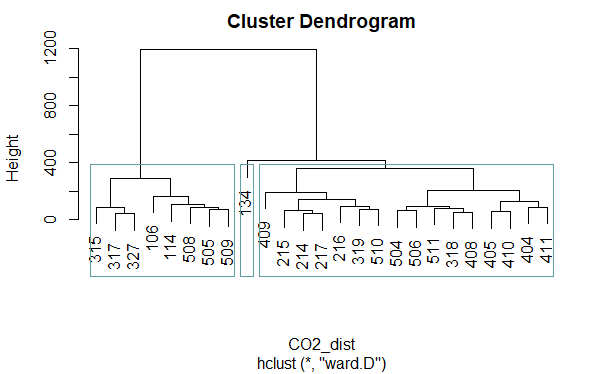

```r
plot(fitCO2)
rect.hclust(fitCO2, k=3, border="cadetblue")
```

Same diagram rotated

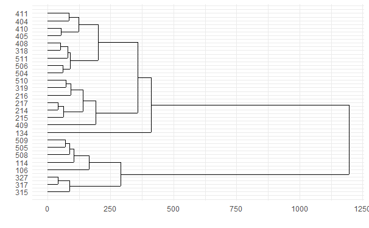

```r
library(ggdendro)
ggdendrogram(fitCO2, rotate = TRUE, theme_dendro = FALSE) +
  theme_minimal() + xlab("") + ylab("")
```

```r
clustered_data <- cutree(fitCO2, k=3)
clustered_data_tidy <- as.data.frame(as.table(clustered_data)) %>% glimpse()
```

```
Observations: 25
Variables: 2
$ Var1 <fct> 106, 114, 134, 214, 215, 216, 217, 315, 317, 318, 319,...
$ Freq <int> 1, 1, 2, 3, 3, 3, 3, 1, 1, 3, 3, 1, 3, 3, 3, 3, 3, 3, ...
```

```r
colnames(clustered_data_tidy) <- c("Room","cluster")
clustered_data_tidy$Room <- as.character(clustered_data_tidy$Room)
aggred$Room <- as.character(aggred$Room) #joining on char values
```

```r
joined_clusters <- aggred %>%
  inner_join(clustered_data_tidy, by = "Room") %>%
  glimpse()
```

```
Observations: 275
Variables: 4
$ Room    <chr> "106", "114", "134", "214", "215", "216", "217", "3...
$ Hour    <dbl> 8, 8, 8, 8, 8, 8, 8, 8, 8, 8, 8, 8, 8, 8, 8, 8, 8, ...
$ Value   <dbl> 528.7258, 593.8548, 684.5143, 570.8943, 569.1918, 5...
$ cluster <int> 1, 1, 2, 3, 3, 3, 3, 1, 1, 3, 3, 1, 3, 3, 3, 3, 3, ...
```

Output joined clusters for further plotly charts

```r
write.csv(joined_clusters,"C:/Users/iced/Documents/HY/Year1/DS project/data/joined_clustersKSN.csv", row.names = FALSE)
```

How many Rooms per cluster:

```r
table(clustered_data_tidy$cluster)
```

```
 1  2  3
 8  1 16
```

Visualizing clusters

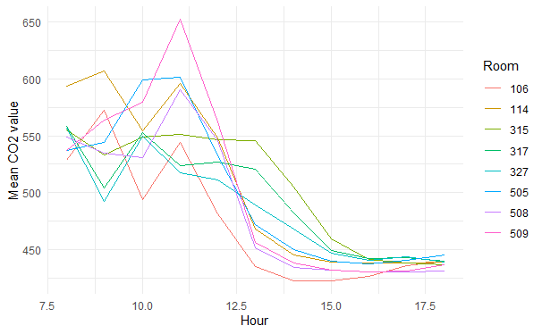

```r
cluster1 <- joined_clusters %>% filter(cluster == "1")

cluster1 %>%
  ggplot( aes(x=Hour, y=Value, group=Room, color=Room)) +
    geom_line() + ylab("Mean CO2 value") + theme_minimal()
```

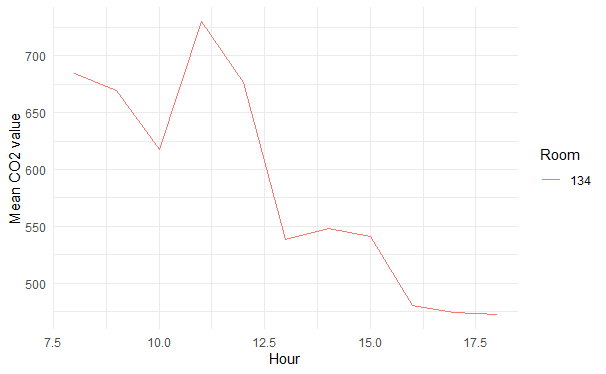

```r
cluster2 <- joined_clusters %>% filter(cluster == "2")

cluster2 %>%
  ggplot( aes(x=Hour, y=Value, group=Room, color=Room)) +
    geom_line() + ylab("Mean CO2 value") + theme_minimal()
```

```r
cluster3 <- joined_clusters %>% filter(cluster == "3")

cluster3 %>%
  ggplot( aes(x=Hour, y=Value, group=Room, color=Room)) +
    geom_line() + ylab("Mean CO2 value") + theme_minimal()
```

[output not shown]

Cluster-colored graph

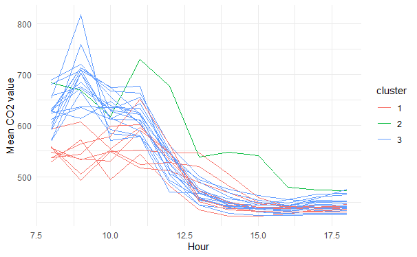

```r
joined_clusters$cluster<-as.character(joined_clusters$cluster)
joined_clusters %>%
  ggplot( aes(x=Hour, y=Value, group=Room, color=cluster)) +
    geom_line() + ylab("Mean CO2 value") + theme_minimal()
```